# Data Exploration and Hypothesis Generation

## Exploring Groups with Facets

Given the results of these last exercises, we might wonder about when planes take off from each airport. One easy to way to look into this question would be to use a facet. A good plot for this question would be a histogram and we could look at the differences by mapping `origin` to fill:

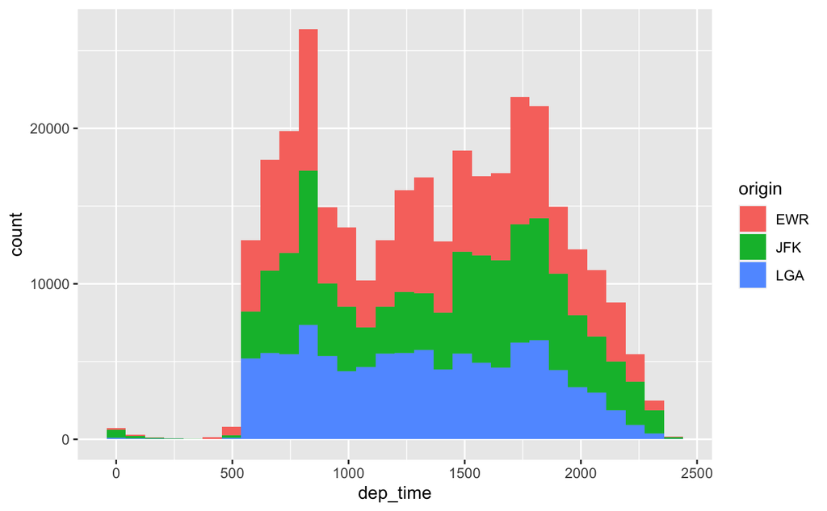

```r
ggplot(flight.data, aes(x = dep_time, fill = origin)) +
  geom_histogram()
```

That’s actually pretty informative. But we could also use a facet like this:

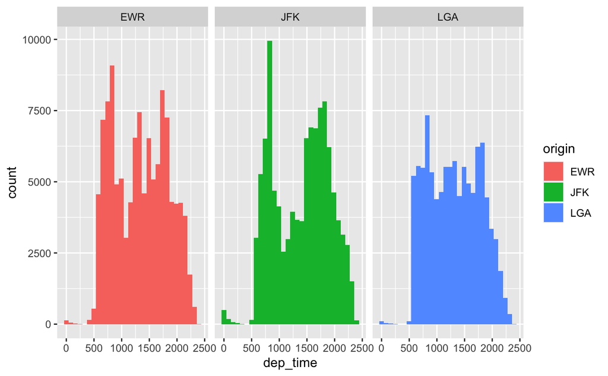

```r
ggplot(flight.data, aes(x = dep_time, fill = origin)) +
  geom_histogram() +
  facet_wrap(~ origin)
```

All we added to our plot was `facet_wrap(~ origin)`. In English, this means “split the plot by (`~`) `origin`. Because these plots are really tall, it might be better to split them into rows instead of columns with the `nrow =` argument:

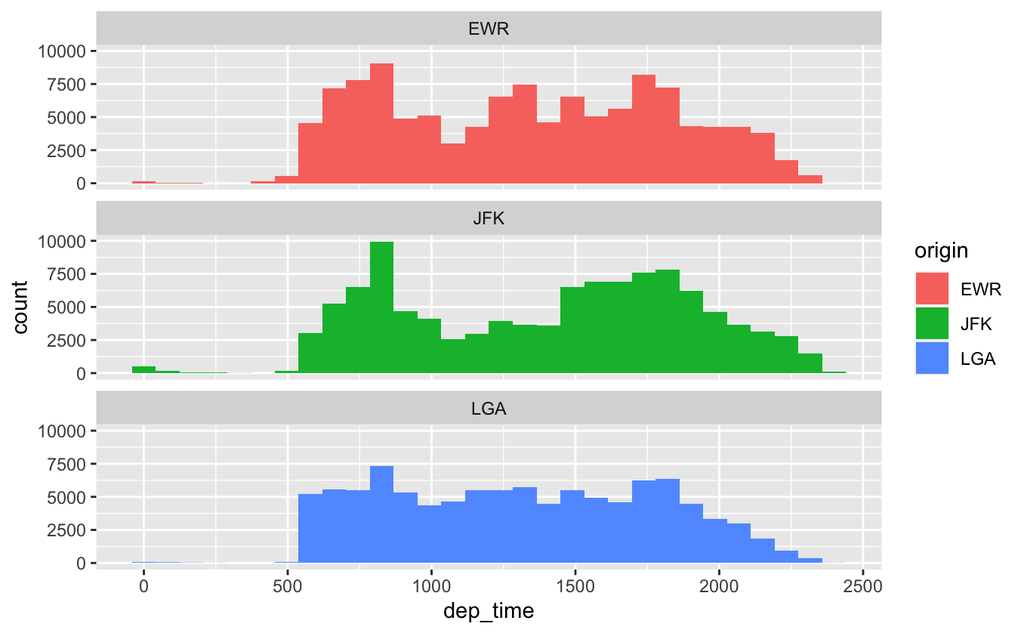

```r
ggplot(flight.data, aes(x = dep_time, fill = origin)) +
  geom_histogram() +
  facet_wrap(~ origin, nrow = 3)
```

### Exercises

1. Use a facet to visualize the relationship between `distance` and `arr_delay`.
2. Is there a relationship between these variables? Does it vary depending on `carrier`?

## How to Make your Visuals More Effective

`ggplot2` offers a number of different ways to make your visuals more effective. An effective visual is one that “stands on its own.” In other words, If you showed someone an effective visual, they would be able to understand what they are looking at. Some of the primary things we want to do to make our visuals more effective are:

- Use good labels for axes, legends, colors, etc.
- Modify the colors of the plot
- Adjust the axis scales

There are many more ways to modify plots, but we’ll focus on these three main aspects.

### Using Good Labels

This is a pretty good plot:

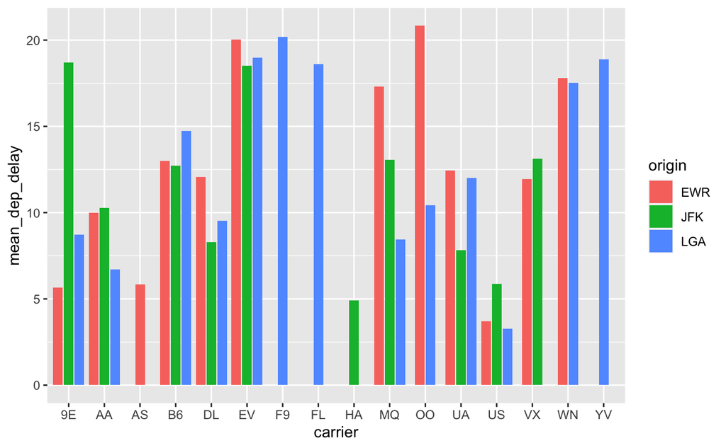

```r
flight.data %>%
  group_by(carrier, origin) %>%
  summarize(mean_dep_delay = mean(dep_delay)) %>%
  ggplot(mapping = aes(x = carrier, y = mean_dep_delay, fill = origin)) +
  geom_col(position = position_dodge2(preserve = "single"))
```

but we can make it better. Let’s start by using better axis titles. We can do that with the `labs()` function:

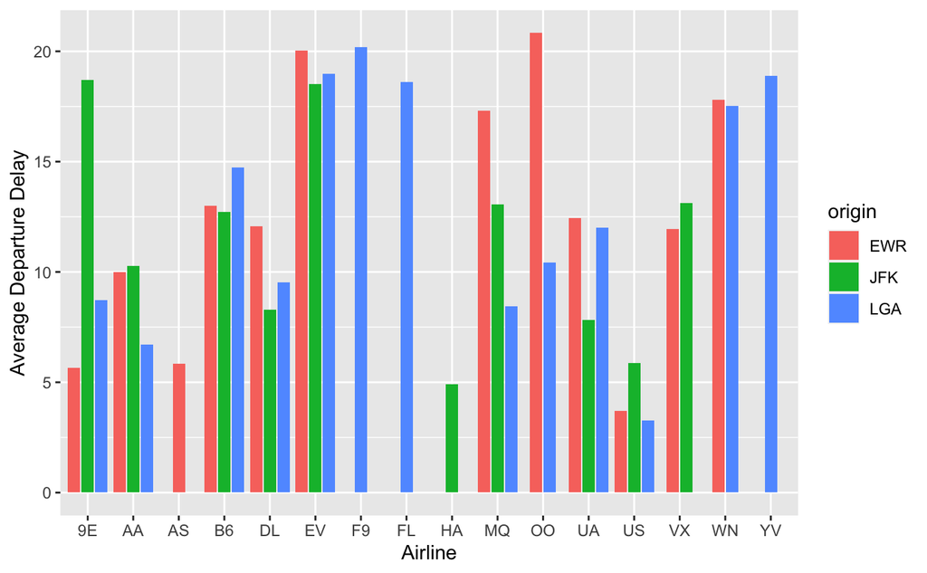

```r
flight.data %>%
  group_by(carrier, origin) %>%
  summarize(mean_dep_delay = mean(dep_delay)) %>%
  ggplot(mapping = aes(x = carrier, y = mean_dep_delay, fill = origin)) +
  geom_col(position = position_dodge2(preserve = "single")) +
  # add labels
  labs(x = "Airline",
       y = "Average Departure Delay")
```

Better. Now let’s add a title and change the name of the legend:

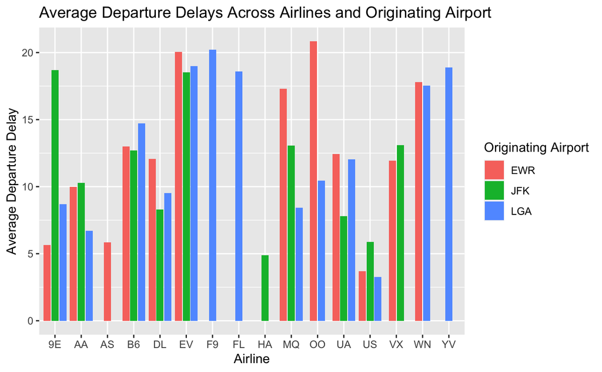

```r
flight.data %>%
  group_by(carrier, origin) %>%
  summarize(mean_dep_delay = mean(dep_delay)) %>%
  ggplot(mapping = aes(x = carrier, y = mean_dep_delay, fill = origin)) +
  geom_col(position = position_dodge2(preserve = "single")) +
  # add labels
  labs(x = "Airline",
       y = "Average Departure Delay",
       title = "Average Departure Delays Across Airlines and Originating Airport",
       fill = "Originating Airport")
```

It might make it easier to approximate the y-axis values if we add some horizontal lines. We can do that be adding `theme_linedraw()`:

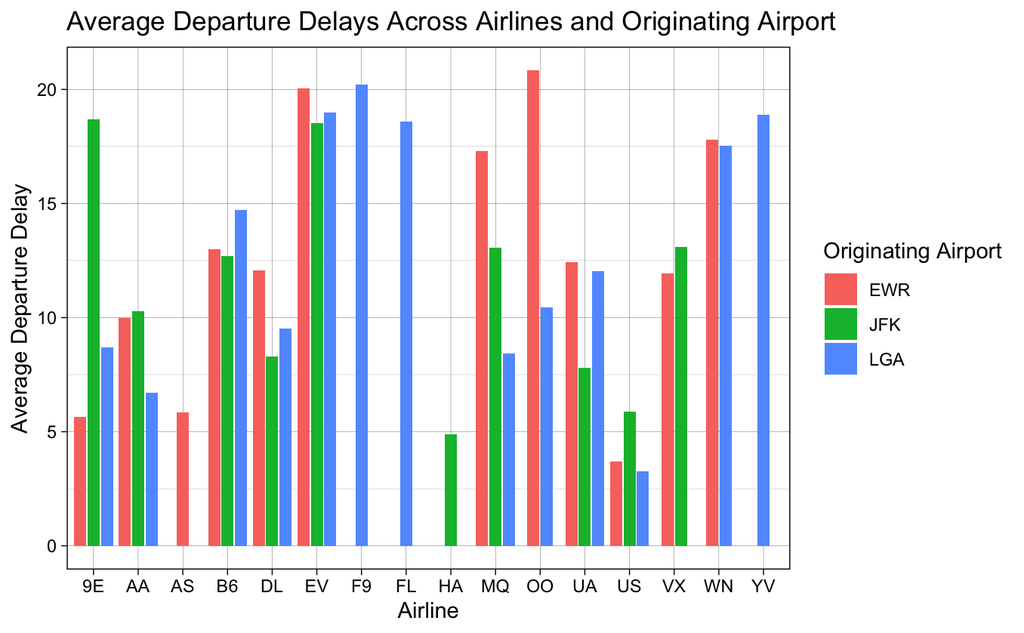

```r
flight.data %>%
  group_by(carrier, origin) %>%
  summarize(mean_dep_delay = mean(dep_delay)) %>%
  ggplot(mapping = aes(x = carrier, y = mean_dep_delay, fill = origin)) +
  geom_col(position = position_dodge2(preserve = "single")) +
  # add labels
  labs(x = "Airline",
       y = "Average Departure Delay",
       title = "Average Departure Delays Across Airlines and Originating Airport",
       fill = "Originating Airport") +
  theme_linedraw()
```

Now let’s move the legend to the top of the plot:

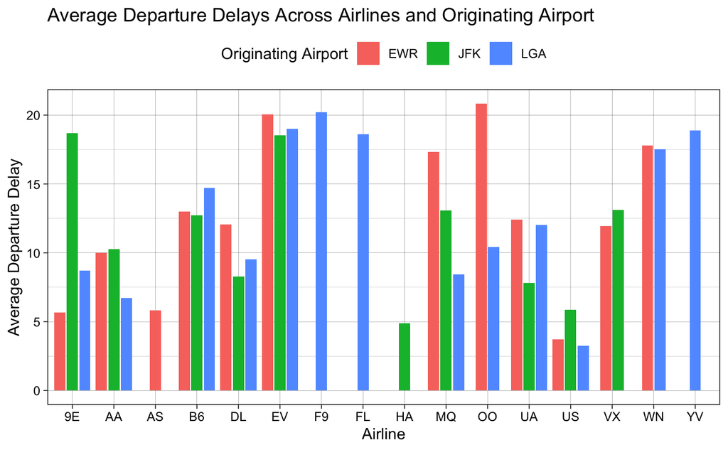

```r
flight.data %>%
  group_by(carrier, origin) %>%
  summarize(mean_dep_delay = mean(dep_delay)) %>%
  ggplot(mapping = aes(x = carrier, y = mean_dep_delay, fill = origin)) +
  geom_col(position = position_dodge2(preserve = "single")) +
  # add labels
  labs(x = "Airline",
       y = "Average Departure Delay",
       title = "Average Departure Delays Across Airlines and Originating Airport",
       fill = "Originating Airport") +
  theme_linedraw() +
  # reposition the legend location
  theme(legend.position = "top")
```

We might want to change the colors of the bars themselves. For example, we might want to make the colors more friendly to colorblind viewers. The `ggthemes` package offers a great option for this. You’ll need to install the package if you haven’t already. Because we want to adjust the `fill` colors, we use `scale_fill_*` then the name of the fill we want. To use the colorblind fill from `ggthemes`, we’ll use `scale_fill_colorblind()`:

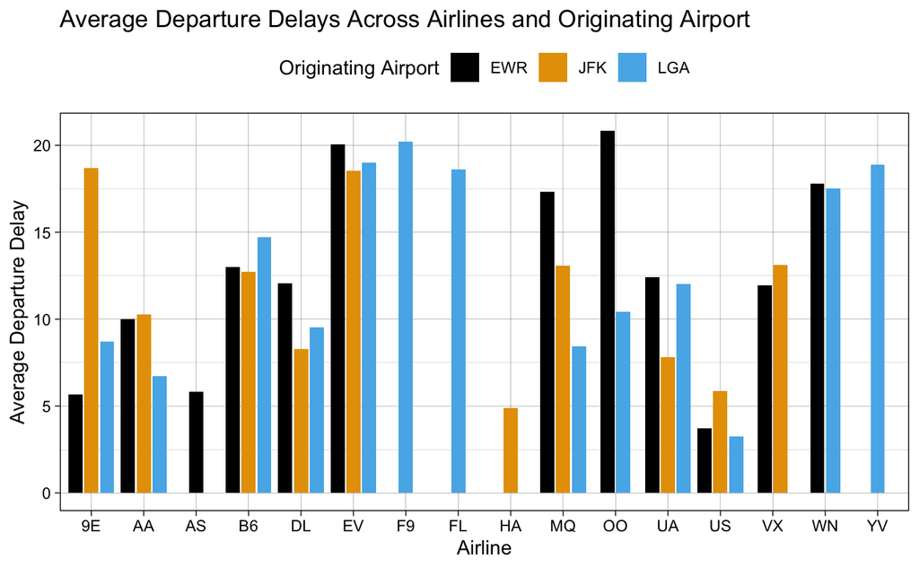

```r
flight.data %>%
  group_by(carrier, origin) %>%
  summarize(mean_dep_delay = mean(dep_delay)) %>%
  ggplot(mapping = aes(x = carrier, y = mean_dep_delay, fill = origin)) +
  geom_col(position = position_dodge2(preserve = "single")) +
  # add labels
  labs(x = "Airline",
       y = "Average Departure Delay",
       title = "Average Departure Delays Across Airlines and Originating Airport",
       fill = "Originating Airport") +
  theme_linedraw() +
  # reposition the legend location
  theme(legend.position = "top") +
  ggthemes::scale_fill_colorblind()
```

We might, instead, want to pick custom colors. Maybe UCR colors? We can do that with `scale_fill_manual()`. To set the colors we want, we can supply HTML color codes to the `values =`argument. (You can find UCR’s official HTML color codes here: [UCR Colors](https://brand.ucr.edu/ucr-colors).)

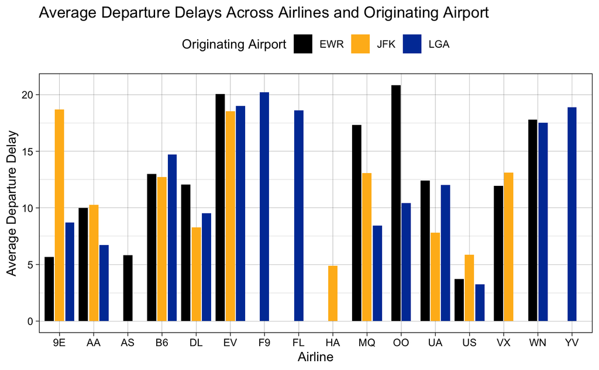

```r
flight.data %>%
  group_by(carrier, origin) %>%
  summarize(mean_dep_delay = mean(dep_delay)) %>%
  ggplot(mapping = aes(x = carrier, y = mean_dep_delay, fill = origin)) +
  geom_col(position = position_dodge2(preserve = "single")) +
  # add labels
  labs(x = "Airline",
       y = "Average Departure Delay",
       title = "Average Departure Delays Across Airlines and Originating Airport",
       fill = "Originating Airport") +
  theme_linedraw() +
  # reposition the legend location
  theme(legend.position = "top") +
  scale_fill_manual(values = c("black", "#FFB81C", "#003DA5"))
```

This is good, but we can still do better. What airports are EWR, JFK, and LGA? You might know, but not everyone will. Let’s give those better names. To do so, we return to the `scale_fill_manual()` function but this time to add a `labels =` argument:

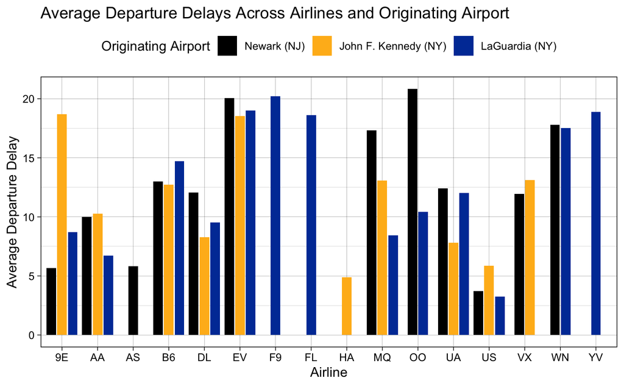

```r
flight.data %>%
  group_by(carrier, origin) %>%
  summarize(mean_dep_delay = mean(dep_delay)) %>%
  ggplot(mapping = aes(x = carrier, y = mean_dep_delay, fill = origin)) +
  geom_col(position = position_dodge2(preserve = "single")) +
  # add labels
  labs(x = "Airline",
       y = "Average Departure Delay",
       title = "Average Departure Delays Across Airlines and Originating Airport",
       fill = "Originating Airport") +
  theme_linedraw() +
  # reposition the legend location
  theme(legend.position = "top") +
  scale_fill_manual(values = c("black", "#FFB81C", "#003DA5"),
                    labels = c("Newark (NJ)", "John F. Kennedy (NY)",
                               "LaGuardia (NY)"))
```

We could still do better, but this looks pretty good. Let’s use the `patchwork` package to put the old and new plots next to each other:

[figure not shown]

#### Exercises

1. Use your new skills to make one of the plots we make earlier in class more effective and presentation ready.